# Time Series Covid Project

Reagan Meagher and Megan Riley

#*Modeling Covid19 Time Series*

Covid19 is a worldwide pandemic that will likely define 2020. In the United States, currently over four million people have been infected and over 150,000 have died as a result of Covid19. As the pandemic continues, limiting infections, serious harm, and death is a primary concern for all involved.

As this is a novel illness, we know relatively little, but understanding how Covid19 is spreading and judging the severity of an outbreak can be approximated with the data we have available. In this report we aim to build effective time series models to forecast future Covid19 cases using the techniques we have learned from this Time Series course. ##*Goal One: Data Collection*

The data source we are using is sourced from [The Covid Tracking Project](https://covidtracking.com/).

```r
initial_data_fl <- read.csv(file="https://raw.githubusercontent.com/megnn/TimeSeries_Covid/master/covidtracking_FL_data.csv", header=TRUE)
initial_data_us <- read.csv(file="https://raw.githubusercontent.com/megnn/TimeSeries_Covid/master/covidtracking_US_data.csv", header=TRUE)

initial_data_fl = initial_data_fl[order(nrow(initial_data_fl):1),]
initial_data_us = initial_data_us[order(nrow(initial_data_us):1),]

len_fl = dim(initial_data_fl)[1]
len_us = dim(initial_data_us)[1]
```

Plotting the daily positive cases in Florida and US.

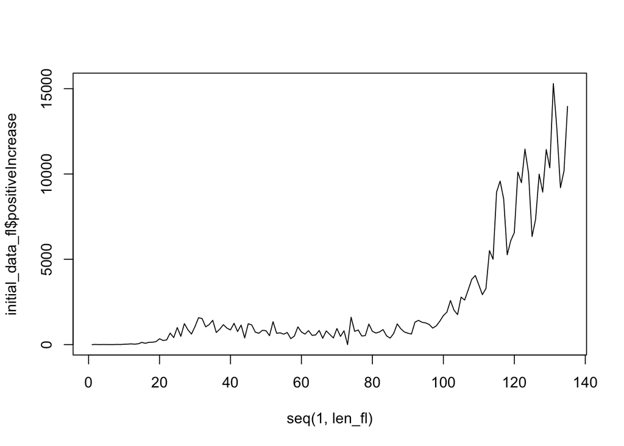

```r
plot(x = seq(1,len_fl), y = initial_data_fl$positiveIncrease, type = "l")
```

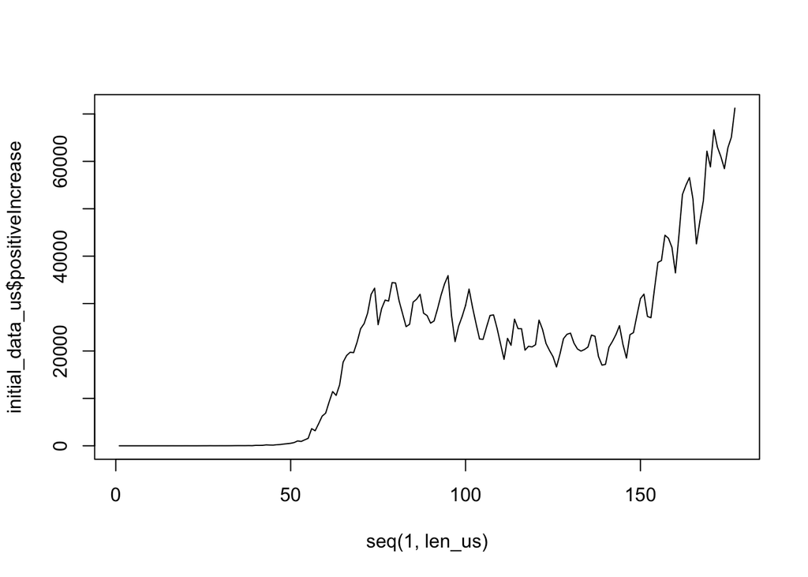

```r
plot(x = seq(1,len_us), y = initial_data_us$positiveIncrease, type = "l")
```

##*Positive Percentage*

Positive Percentage is a statistic that calculates daily positive tests as a percentage of daily overall tests returned. We calculated this column and added it to our data below followed by some visual exploration of the statistic itself.

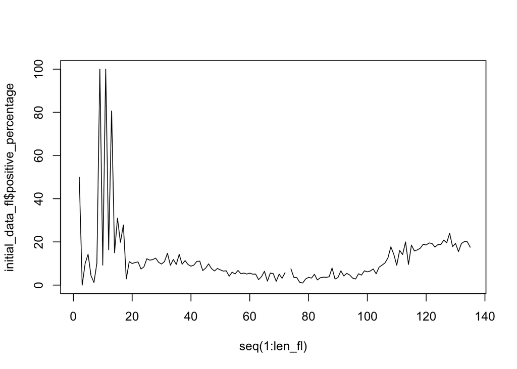

```r
for (i in 1:nrow(initial_data_fl)) {
  n <- round((initial_data_fl$positiveIncrease / initial_data_fl$totalTestResultsIncrease) * 100, digits = 4)
  initial_data_fl$positive_percentage <- n
}

for (i in 1:nrow(initial_data_us)) {
  n <- round((initial_data_us$positiveIncrease / initial_data_us$totalTestResultsIncrease) * 100, digits = 4)
  initial_data_us$positive_percentage <- n
}


#Percent Positive Exploration
plot(x = seq(1:len_fl), y = initial_data_fl$positive_percentage, type = "l")
```

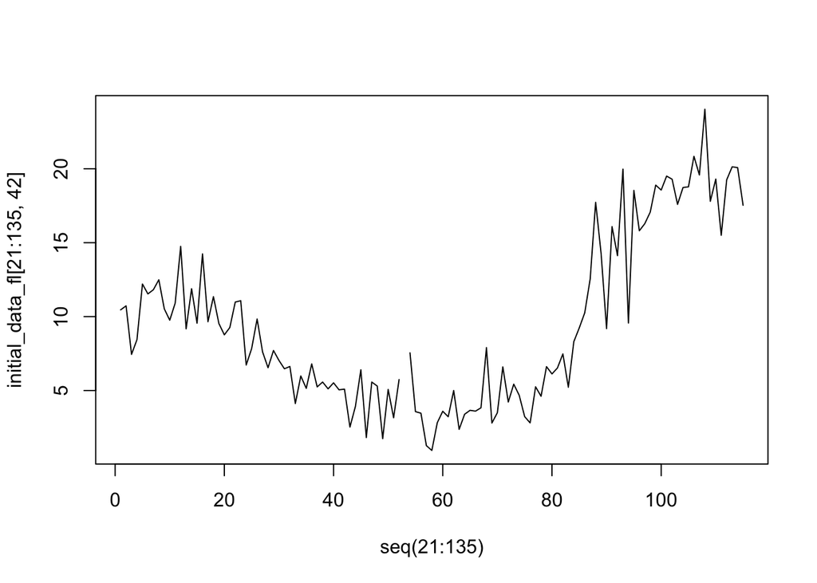

```r
plot(x = seq(21:135), y = initial_data_fl[21:135,42], type = "l")
```

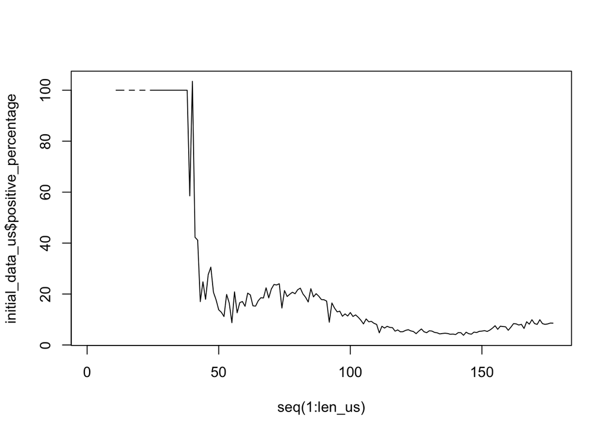

```r
plot(x = seq(1:len_us), y = initial_data_us$positive_percentage, type = "l")
```

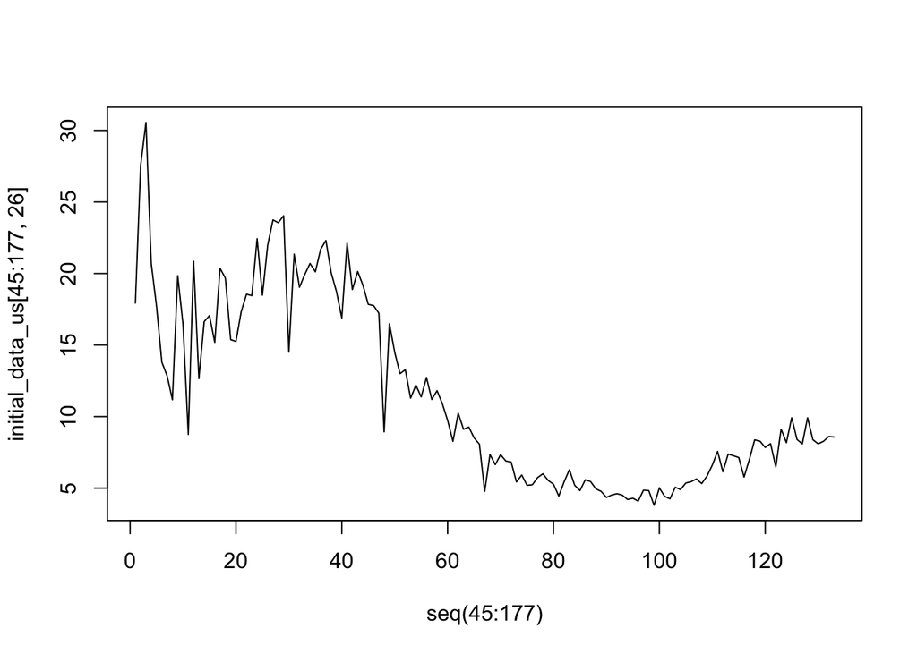

```r
plot(x = seq(45:177), y = initial_data_us[45:177,26], type = "l")
```

Positive Percentage as a metric is a measure of two main things, how many tests are we administering and how many positives are we receiving. If tests are skyrocketing while positive cases are increasing, we would see a stable or even diminishing line which could indicate not a pandemic under control but simply better testing resources but could be interpreted as a pandemic managed.

Keeping tests increasing to continue to keep percent positives level is a good indication we have leveled up our resources to continue to diagnose the pandemic at the same level, but if we need to scale up our testing to keep the same positive percentage, there is more covid spread.

However, an increasing positive percentage is a good indicator that our testing resources may not be up to actually up to tracking the current stage of the pandemic.

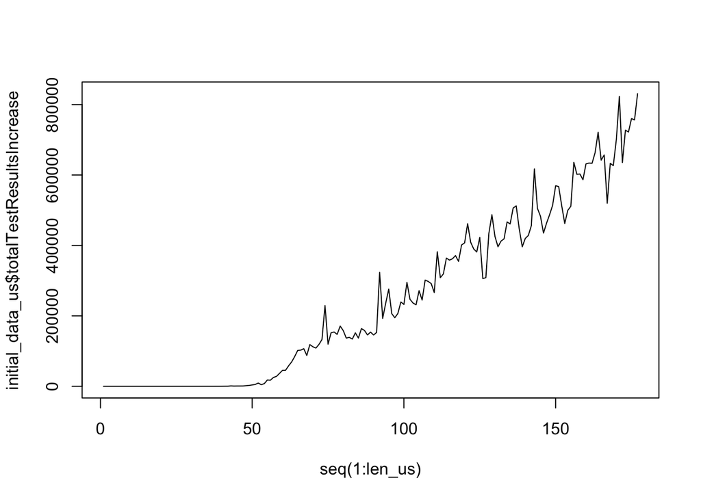

```r
plot(x = seq(1:len_us), y = initial_data_us$totalTestResultsIncrease, type = "l")
```

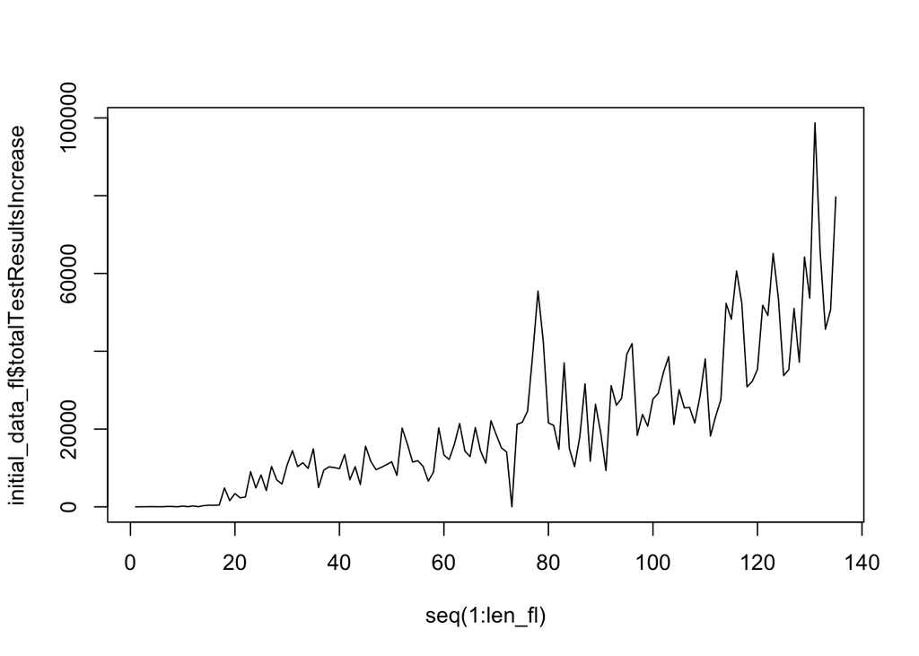

```r
plot(x = seq(1:len_fl), y = initial_data_fl$totalTestResultsIncrease, type = "l")
```

####Data Preperation

In order to model new case numbers by day we set up dataframes with only our date and positive increase amount per day.

```r
newcases_fl <- dplyr::select(initial_data_fl, c("date", "positiveIncrease"))
newcases_us <- dplyr::select(initial_data_us, c("date", "positiveIncrease"))
```

####Checking for NAs

We can see with the missing value analysis below that we have no NAs present in our new case data.

```r
#Checking for NAs
md.pattern(newcases_fl)
```

```
##  /\     /\
## {  `---'  }
## {  O   O  }
## ==>  V <==  No need for mice. This data set is completely observed.
##  \  \|/  /
##   `-----'
```

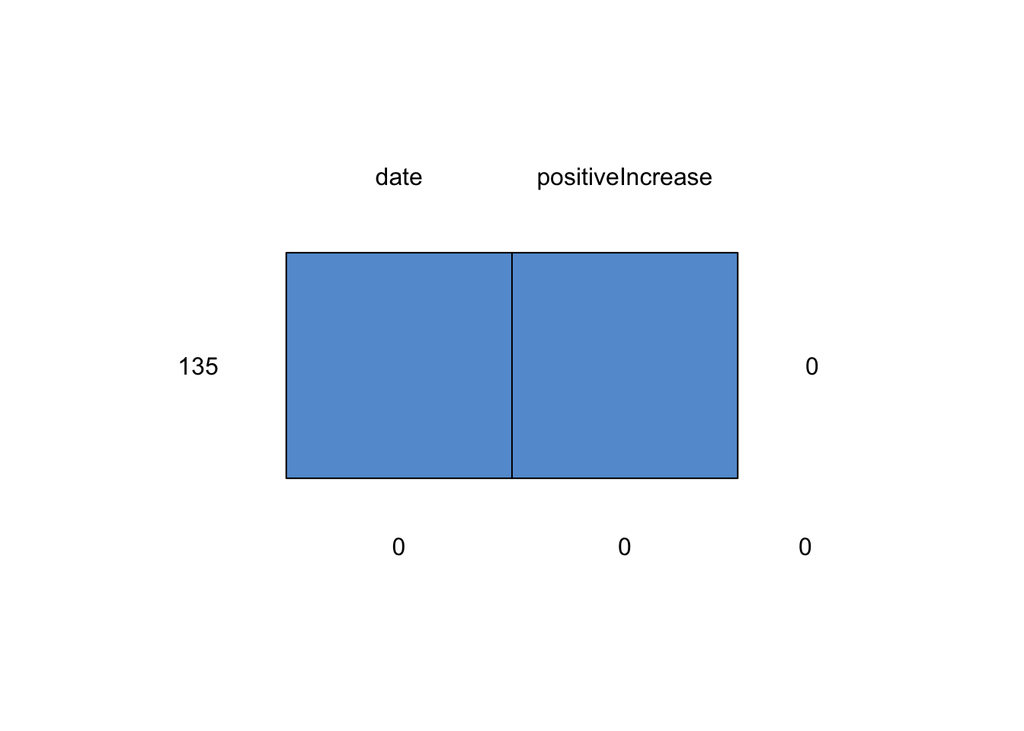

```
##     date positiveIncrease
## 135    1                1 0
##        0                0 0
```

```r
# No NAs present


#Checking for NAs
md.pattern(newcases_us)
```

```
##  /\     /\
## {  `---'  }
## {  O   O  }
## ==>  V <==  No need for mice. This data set is completely observed.
##  \  \|/  /
##   `-----'
```

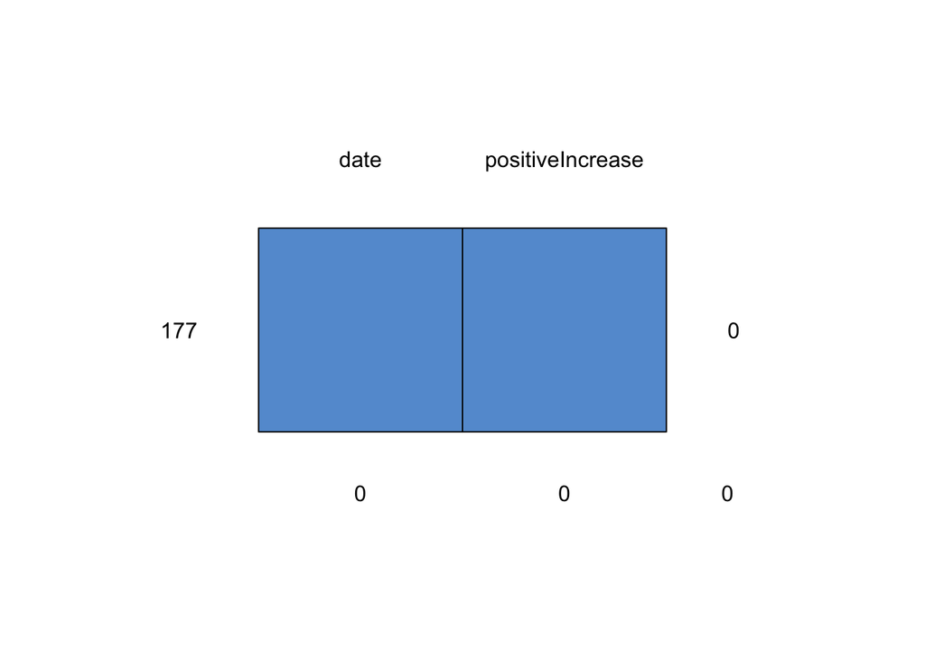

```
##     date positiveIncrease
## 177    1                1 0
##        0                0 0
```

```r
#No NAs present
```

(Does this really need to be in the univariate section? If so should we drop our lesser models? ) ###**Florida Daily Cases:**

As we can see below, the daily new positive cases in Florida is in recent days spiking. We also have the ACFs and Spectral Density plots laid out. In the ACFs we see a clear pattern of slowly dampening frequencies, indicative of non stationarity. And within the spectral density plot we see a peak at zero which could indicate stationary wandering or an aperiodic trend. Given our data shows a strong upward trend in recent days, the evidence at hand strongly points to the new positive cases behaving in a non stationary way.

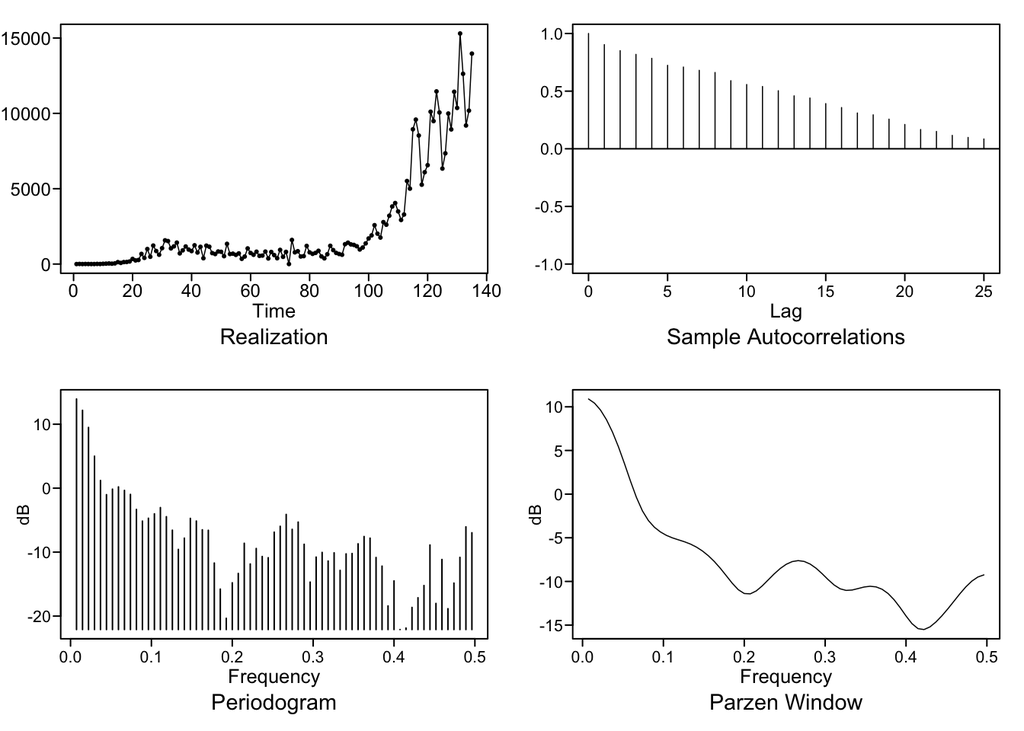

[output not shown]

[output cut: 39 more lines]

```r
plotts.sample.wge(newcases_fl$positiveIncrease)
```

###Florida Cases - Baseline Model One

To model Florida cases we start with a base model. We can see that the most favored model by BIC is an AR(1). So we begin by building that model. Our AR(1) has a phi of .975, quite close to the unit circle, which we expect to model strongly wandering behavior.

This model has an AIC estimate of 14.01.

In order to estimate an average ASE, we are running this model over segments of our data with 54 iterations. In each case training with at least seventy data points and predicting on twelve. Overall this produces an average ASE of 6,353,070.

```r
aic5.wge(newcases_fl$positiveIncrease, type = 'bic')
```

[output not shown]

```
##      p    q        bic
## 4    1    0   14.05549
## 8    2    1   14.06332
## 3    0    2   14.87017
## 2    0    1   15.48262
## 1    0    0   16.29580
```

```r
fl_ar_1 = est.ar.wge(newcases_fl$positiveIncrease, p = 1)
```

```
##
## Coefficients of Original polynomial:
## 0.9749
##
## Factor                 Roots                Abs Recip    System Freq
## 1-0.9749B              1.0258               0.9749       0.0000
##
##
##
## Coefficients of Original polynomial:
## 0.9749
##
## Factor                 Roots                Abs Recip    System Freq
## 1-0.9749B              1.0258               0.9749       0.0000
##
##
```

```r
fl_ar_1$aic
```

```
## [1] 14.01245
```

```r
trainingSize = 70
horizon = 12
ASEHolder = numeric()

for( i in 1:(135-(trainingSize + horizon) + 1))
{

  forecasts = fore.aruma.wge(newcases_fl$positiveIncrease[i:(i+(trainingSize-1))],phi = fl_ar_1$phi, n.ahead = horizon, plot = FALSE)

  ASE = mean((newcases_fl$positiveIncrease[(trainingSize+i):(trainingSize+ i + (horizon) - 1)] - forecasts$f)^2)
  ASEHolder[i] = ASE

}

ASEHolder
```

```
##  [1]   165730.08   214431.03   142140.69   603702.26   605351.70
##  [6]    64677.95    73566.75   118385.39   110395.99   200958.47
## [11]    68651.54   120792.05   134645.81   132961.45   289116.88
## [16]   420109.30   221265.76    90925.40   159264.48   362529.02
## [21]   719994.24   935953.58   311875.66   458390.45   683133.70
## [26]  1052417.94  1766623.49  2950069.35  3145693.05  2713412.08
## [31]  2249231.65  3052685.64  2452301.49  7867437.40 14091604.22
## [36] 13025656.21 14332773.78 12521299.21 10891337.53 13671140.94
## [41] 19561231.99 29565884.89 30815221.76 15363779.10 18534545.20
## [46]  4803457.78  4778354.91  6925530.05 22292720.46 25080195.42
## [51] 25435858.65  8267965.11  9762663.04  8685738.16
```

[figure not shown]

```r
#Distribution of ASEs on Two Week Periods
hist(ASEHolder, xlab = "ASE of model at a given Training Set",  main = "ASE Distribution for Model ARIMA(2,1,1) for Florida Data")
```

```r
#Mean ASE
WindowedASE = mean(ASEHolder)
WindowedASE
```

```
## [1] 6353070
```

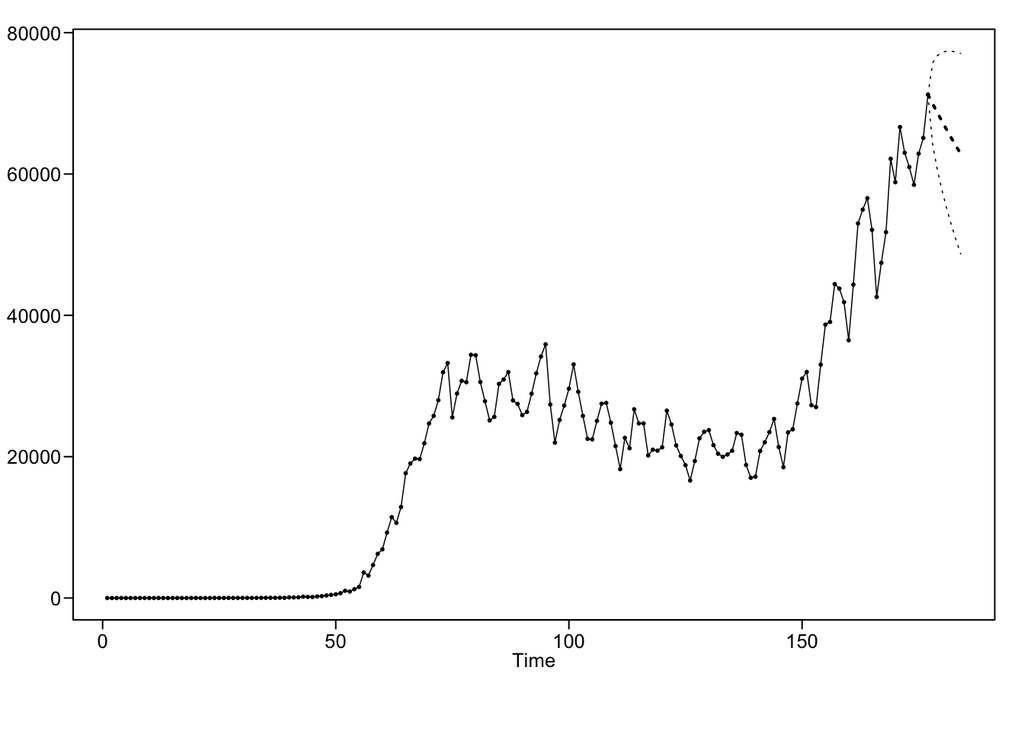

```r
short_fl_ar1 = fore.aruma.wge(newcases_us$positiveIncrease,phi = fl_ar_1$phi, n.ahead = 7, plot = TRUE)
```

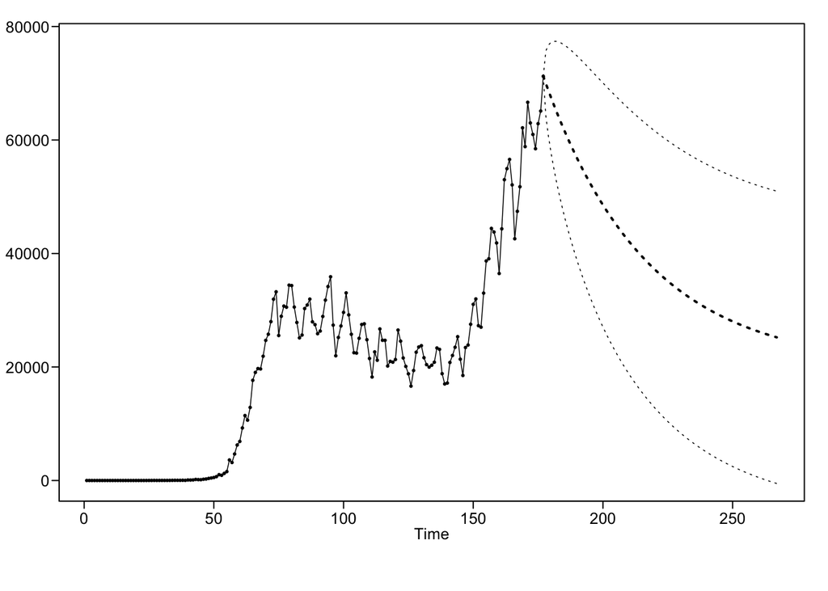

```r
long_us_ar1 = fore.aruma.wge(newcases_us$positiveIncrease,phi = fl_ar_1$phi, n.ahead = 90, plot = TRUE)
```

###Florida Cases - Baseline Model Two

```r
aic5.wge(newcases_fl$positiveIncrease)
```

[output not shown]

```
##      p    q        aic
## 8    2    1   13.97724
## 4    1    0   14.01245
## 3    0    2   14.80561
## 2    0    1   15.43958
## 1    0    0   16.27428
```

```r
aic5.wge(newcases_fl$positiveIncrease, type = 'bic')
```

[output not shown]

```
##      p    q        bic
## 4    1    0   14.05549
## 8    2    1   14.06332
## 3    0    2   14.87017
## 2    0    1   15.48262
## 1    0    0   16.29580
```

```r
fl_arma_21 = est.arma.wge(newcases_fl$positiveIncrease, p = 2, q = 1)
```

```
##
## Coefficients of Original polynomial:
## -0.0070 0.9634
##
## Factor                 Roots                Abs Recip    System Freq
## 1+0.9850B             -1.0152               0.9850       0.5000
## 1-0.9780B              1.0225               0.9780       0.0000
##
##
```

```r
fl_arma_21
```

[output not shown]

```r
fl_arma_21$aic
```

```
## [1] 13.97724
```

```r
trainingSize = 70
horizon = 12
ASEHolder = numeric()

for( i in 1:(135-(trainingSize + horizon) + 1))
{

  forecasts = fore.aruma.wge(newcases_fl$positiveIncrease[i:(i+(trainingSize-1))],phi = fl_arma_21$phi, theta = fl_arma_21$theta, n.ahead = horizon, plot = FALSE)

  ASE = mean((newcases_fl$positiveIncrease[(trainingSize+i):(trainingSize+ i + (horizon) - 1)] - forecasts$f)^2)
  ASEHolder[i] = ASE

}

ASEHolder
```

```
##  [1]   167627.68   206397.80   137941.85   555602.91   521952.39
##  [6]   102153.75    87478.32   108624.36   183158.65   270619.99
## [11]    71089.92   115747.03   149317.00   133958.81   312340.25
## [16]   400954.76   247387.67    93284.93   158738.58   355742.35
## [21]   730532.31   931261.68   316047.95   439025.90   684184.64
## [26]  1021243.81  1771168.82  2899014.83  3188439.68  2658403.85
## [31]  2249266.64  2963186.04  2424907.70  7652197.48 14157083.00
## [36] 12795601.42 14103207.41 12339977.68 10590941.21 13337047.71
## [41] 19029966.10 29257992.40 30450023.78 15124656.10 17509801.44
## [46]  4594811.59  4654248.02  6537591.44 20214870.57 25595997.81
## [51] 23181259.41  8136658.95  8319256.74  8111410.44
```

[figure not shown]

```r
#Distribution of ASEs on Two Week Periods
hist(ASEHolder, xlab = "ASE of model at a given Training Set",  main = "ASE Distribution for Model ARIMA(2,1,1) for Florida Data")
```

```r
#Mean ASE
WindowedASE = mean(ASEHolder)
WindowedASE
```

```
## [1] 6154656
```

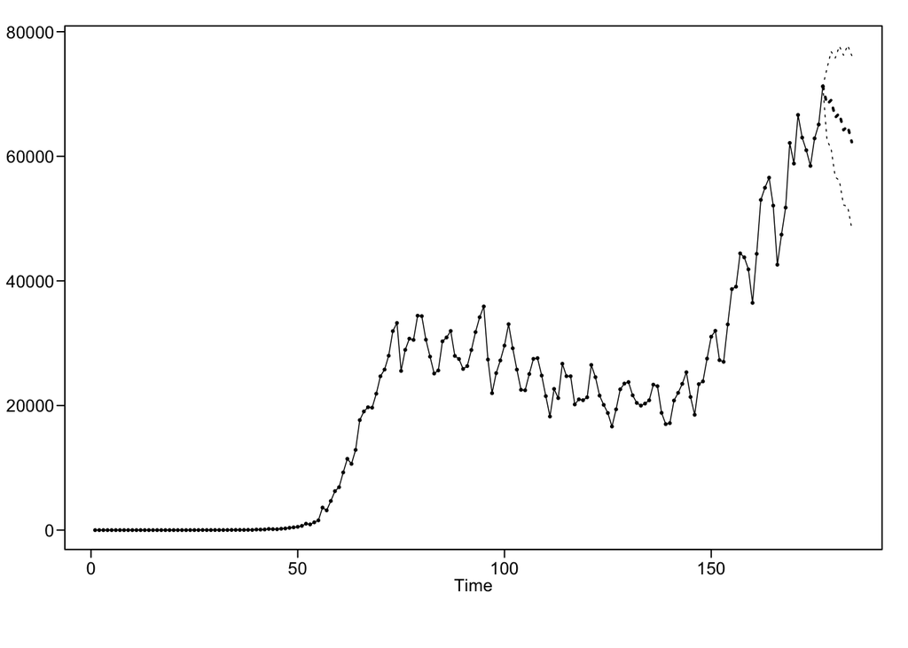

```r
short_fl_ar1 = fore.aruma.wge(newcases_us$positiveIncrease,phi = fl_arma_21$phi,theta = fl_arma_21$theta, n.ahead = 7, plot = TRUE)
```

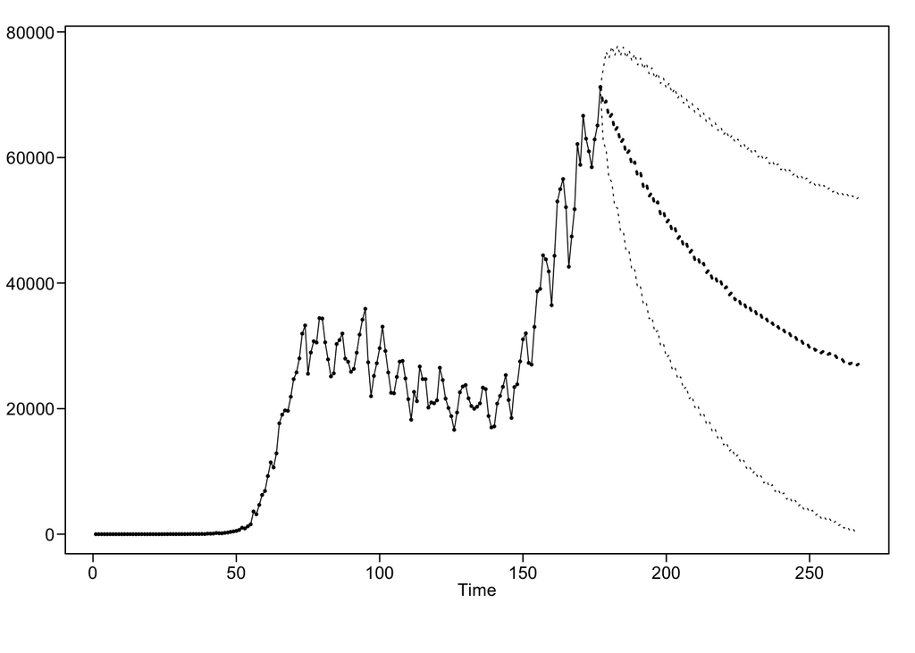

```r
long_us_ar1 = fore.aruma.wge(newcases_us$positiveIncrease,phi = fl_arma_21$phi,theta = fl_arma_21$theta, n.ahead = 90, plot = TRUE)
```

###**US Daily Cases:**

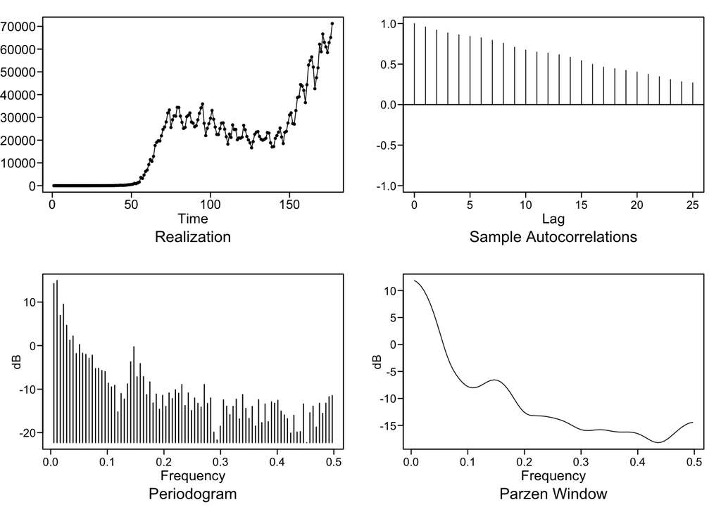

[output not shown]

[output cut: 50 more lines]

```r
plotts.sample.wge(newcases_us$positiveIncrease)
```

[figure not shown]

```r
plot(x = seq(1,len_us), y = newcases_us$positiveIncrease, type = "l", main = 'United States Covid-19 Daily Positive Cases', xlab = 'Time (Days From Start of Pandemic)', ylab = 'Positive Daily Cases')
```

###US Model One - AR 1

```r
aic5.wge(newcases_us$positiveIncrease)
```

[output not shown]

```
##      p    q        aic
## 6    1    2   15.95786
## 4    1    0   15.96008
## 3    0    2   17.57501
## 2    0    1   18.44652
## 1    0    0   19.55796
```

```r
aic5.wge(newcases_us$positiveIncrease, type = 'bic')
```

[output not shown]

```
##      p    q        bic
## 4    1    0   15.99597
## 6    1    2   16.02964
## 3    0    2   17.62884
## 2    0    1   18.48240
## 1    0    0   19.57590
```

```r
us_ar_1 = est.ar.wge(newcases_us$positiveIncrease, p = 1)
```

```
##
## Coefficients of Original polynomial:
## 0.9953
##
## Factor                 Roots                Abs Recip    System Freq
## 1-0.9953B              1.0048               0.9953       0.0000
##
##
##
## Coefficients of Original polynomial:
## 0.9953
##
## Factor                 Roots                Abs Recip    System Freq
## 1-0.9953B              1.0048               0.9953       0.0000
##
##
```

```r
us_ar_1
```

[output not shown]

[output cut: 46 more lines]

```r
us_ar_1$aic
```

```
## [1] 15.96008
```

```r
trainingSize = 70
horizon = 12
ASEHolder = numeric()

for( i in 1:(177-(trainingSize + horizon) + 1))
{

  forecasts = fore.aruma.wge(newcases_us$positiveIncrease[i:(i+(trainingSize-1))],phi = us_ar_1$phi, n.ahead = horizon, plot = FALSE)

  ASE = mean((newcases_us$positiveIncrease[(trainingSize+i):(trainingSize+ i + (horizon) - 1)] - forecasts$f)^2)
  ASEHolder[i] = ASE

}

ASEHolder
```

```
##  [1]  46765465  33957060  16406814  11032655  16834401  34390599  10672049
##  [8]   7685692   8588906  30691062  32722175   8254324  11455442  37427514
## [15]  32486367  13921863  16785118  22528022  15080506  19584514  28969946
## [22]  25252597  17310271  29795448  56984649  87461508  10287054  32485198
## [29]  11995908  15801369  30529064  80476502  31943686  10304278   9651519
## [36]  10106172  10336202  26140934  30400804  11158037   8289142  27289328
## [43]   5563992   8633160  29920307  17653841  18091115   7941469   7275995
## [50]   7504158   7040090  33100294  18089518   4655636   4685388   9521770
## [57]  24291739   7296000   8520103  13204985  14915637   5643306   6176373
## [64]   6865101   6724501   6911999  11766065  12267951  28080348  61663458
## [71]  67922268  32381119  33496623  43419015  48623292 131447671 241193170
## [78] 160497304 164999780 122035018 113017461 145220487 315101574 375748427
## [85] 209599623 105500019 113646248  78544008 105605579 188316691 387758556
## [92] 191624152  64028381  59271946  61272671 130141068
```

[figure not shown]

```r
#Distribution of ASEs on Two Week Periods
hist(ASEHolder, xlab = "ASE of model at a given Training Set",  main = "ASE Distribution for Model ARIMA(2,1,1) for Florida Data")
```

```r
#Mean ASE
WindowedASE = mean(ASEHolder)
WindowedASE
```

```
## [1] 53277673
```

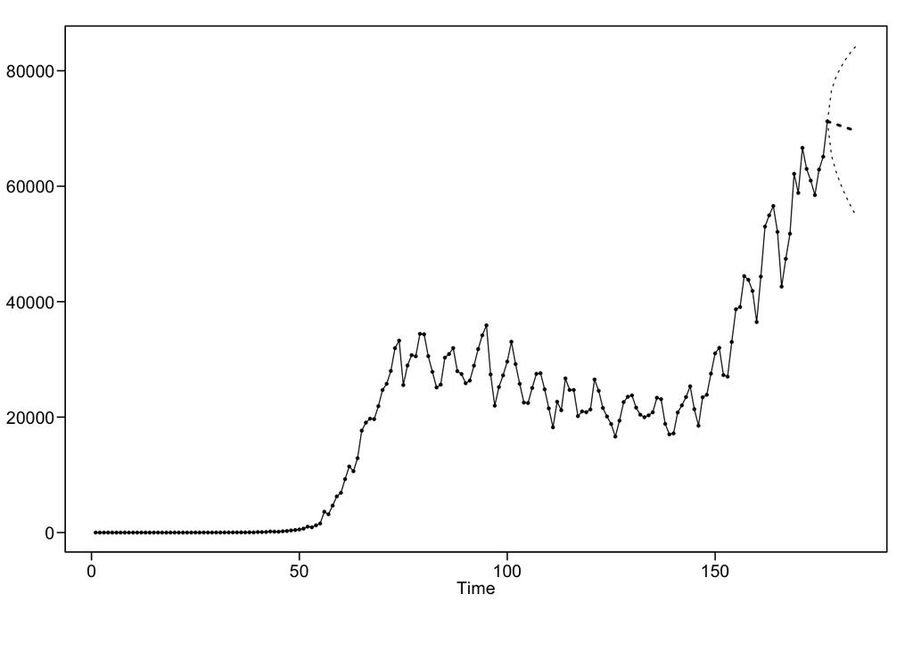

```r
short_fl_ar1 = fore.aruma.wge(newcases_us$positiveIncrease,phi = us_ar_1$phi, n.ahead = 7, plot = TRUE)
```

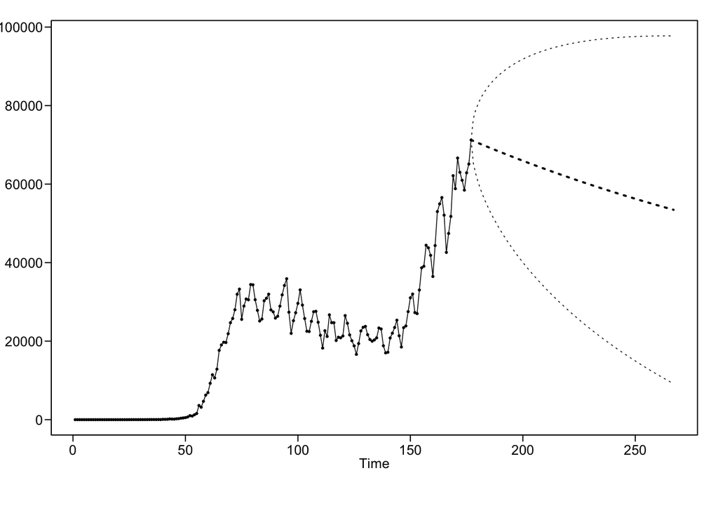

```r
long_us_ar1 = fore.aruma.wge(newcases_us$positiveIncrease,phi = us_ar_1$phi, n.ahead = 90, plot = TRUE)
```

US PArt 2 - ARMA 1 2

```r
aic5.wge(newcases_fl$positiveIncrease)
```

[output not shown]

```
##      p    q        aic
## 8    2    1   13.97724
## 4    1    0   14.01245
## 3    0    2   14.80561
## 2    0    1   15.43958
## 1    0    0   16.27428
```

```r
aic5.wge(newcases_fl$positiveIncrease, type = 'bic')
```

[output not shown]

```
##      p    q        bic
## 4    1    0   14.05549
## 8    2    1   14.06332
## 3    0    2   14.87017
## 2    0    1   15.48262
## 1    0    0   16.29580
```

```r
us_arma_12 = est.arma.wge(newcases_us$positiveIncrease, p = 1, q = 2)
```

```
##
## Coefficients of Original polynomial:
## 0.9919
##
## Factor                 Roots                Abs Recip    System Freq
## 1-0.9919B              1.0081               0.9919       0.0000
##
##
```

```r
us_arma_12
```

[output not shown]

[output cut: 46 more lines]

```r
us_arma_12$aic
```

```
## [1] 15.95786
```

```r
trainingSize = 70
horizon = 12
ASEHolder = numeric()

for( i in 1:(177-(trainingSize + horizon) + 1))
{

  forecasts = fore.aruma.wge(newcases_us$positiveIncrease[i:(i+(trainingSize-1))],phi = us_arma_12$phi, theta = us_arma_12$theta, n.ahead = horizon, plot = FALSE)

  ASE = mean((newcases_us$positiveIncrease[(trainingSize+i):(trainingSize+ i + (horizon) - 1)] - forecasts$f)^2)
  ASEHolder[i] = ASE

}

ASEHolder
```

```
##  [1]  43725973  35579734  15816563  12379608  16077405  63231777   9750780
##  [8]   7422003   7827994  34240666  28525306   6458571  16896630  48641664
## [15]  34877228  15300586  16212745  21221178  19457996  22136822  33803340
## [22]  26312425  16649648  31616011  58839891  87361504  13603088  51265548
## [29]  10098585  16291054  32135503  88968495  21834753   7680905  13124772
## [36]  10367473  12061241  30181559  28890359   8390464  11498325  35163223
## [43]   5970811   9211896  41114819  15001253  16565415  11439564   7133678
## [50]   7371227   7024688  47162686  15221181   3704723   5158051  10417502
## [57]  28158001   5428329  12670962  14728236  15172694   4829085   6396597
## [64]   6776219   6560676   6840061  15007220  12262542  35490861  65797401
## [71]  63948556  24692884  30161102  40875386  45953055 147521940 259676867
## [78] 135521118 159048021 109843644 102674520 144975958 355419374 383704325
## [85] 176877267  88357915 117944780  72816056 113223793 210599000 446366735
## [92] 160337015  55348712  62897740  66463336 160673404
```

[figure not shown]

```r
#Distribution of ASEs on Two Week Periods
hist(ASEHolder, xlab = "ASE of model at a given Training Set",  main = "ASE Distribution for Model ARIMA(2,1,1) for Florida Data")
```

```r
#Mean ASE
WindowedASE = mean(ASEHolder)
WindowedASE
```

```
## [1] 55171440
```

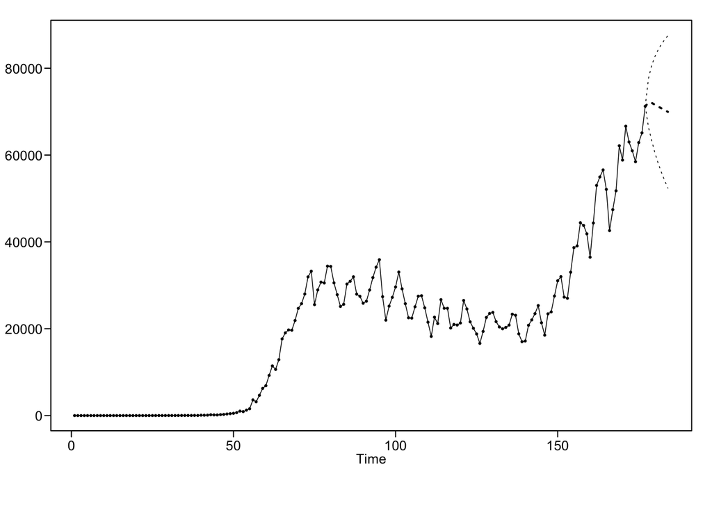

```r
short_fl_ar1 = fore.aruma.wge(newcases_us$positiveIncrease,phi = us_arma_12$phi,theta = us_arma_12$theta, n.ahead = 7, plot = TRUE)
```

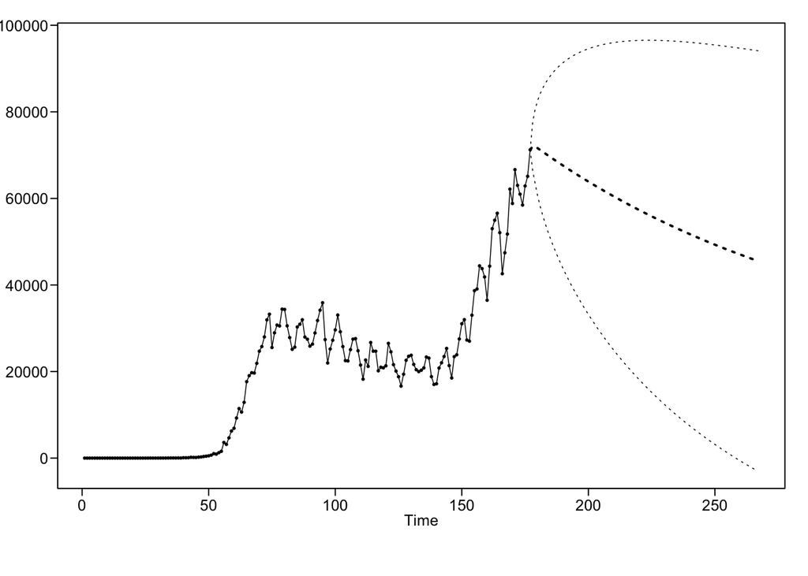

```r
long_us_ar1 = fore.aruma.wge(newcases_us$positiveIncrease,phi = us_arma_12$phi,theta = us_arma_12$theta, n.ahead = 90, plot = TRUE)
```